# act_report

## Report: act_report

When analyzing the dataset from WeRateDogs, I discovered out these interesting insights:

### Insights:

1. Golden Retriever, Labrador Retriever and Pembroke (and slightly also Chihuahuas) are the most favorited breed according to the data; They should be more posted to drive more engagement and hence attract more followers!
2. Wednesday is the most engaging day! Not only do users retweet more but they also like more on that day. That means that anything done on that day can be more impactful than the other days; For example, an exclusive ad posted on Wednesday could drive more sales and increase the exposure rate of the ad.
3. People tend to retweet most when a post is posted from midnight and up to 1am, or at 4pm and up to 5pm; This is the sweet spot to have more engagement from their audience.

   > I suppose this happens because people usually get home from work at 4pm and they get to sleep around midnight. Or maybe their feed is not overcrowded at those hours, so it's easier to catch their attention.
4. It can seem trivial or not that important, but including a hashtag in a tweet improves the likeliness of the tweet getting in front of the right audience and the audience engaging more with the tweet. This was well shown by the data when comparing tweets with and tweets without hashtags.
5. There's a sweet spot somewhere between 110 and 140 text range that somehow seems to create more likes and retweets. This could be because these dog lovers are literate people or maybe that it's just random, but effective.

### Visualizations:

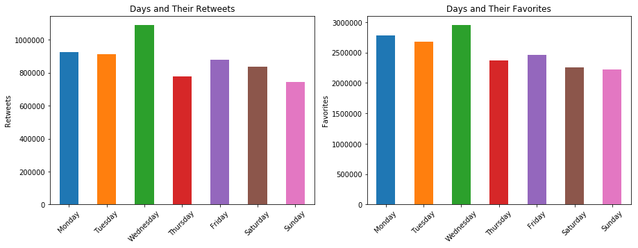

```python
#importing panda and the data
import pandas as pd
import matplotlib.pyplot as plt
from datetime import datetime
df = pd.read_csv("twitter_archive_master.csv")

#Setting up the figure
fig, (ax1, ax2) = plt.subplots(1,2, figsize=(15,5))
df['timestamp'] = pd.to_datetime(df['timestamp'], errors='coerce')
df["day"] = df.timestamp.dt.dayofweek
df.groupby(by="day").retweet_count.sum().plot(kind="bar", title="Days and Their Retweets", ax=ax1)

#Setting labels
plt.xlabel("")
plt.ylabel("Retweets")

#Setting the tick labels
squad = ['Monday','Tuesday','Wednesday','Thursday','Friday','Saturday','Sunday']
ax1.set_xticklabels(squad, minor=False, rotation=45)
ax1.set(xlabel='', ylabel='Retweets');

#The 2nd plot
df.groupby(by="day").favorite_count.sum().plot(kind="bar", title="Days and Their Favorites", ax=ax2, )

#Setting the tick labels
squad = ['Monday','Tuesday','Wednesday','Thursday','Friday','Saturday','Sunday']
ax2.set_xticklabels(squad, minor=False, rotation=45)
ax2.set(xlabel='', ylabel='Favorites');
```

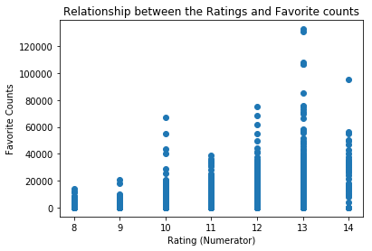

```python
low, high= df.rating_numerator.quantile([.1,.99])
m= df.rating_numerator.between(low, high)
plt.scatter(x= df[m].rating_numerator, y=df[m].favorite_count)
plt.title("Relationship between the Ratings and Favorite counts")
plt.xlabel("Rating (Numerator)")
plt.ylabel("Favorite Counts");
```

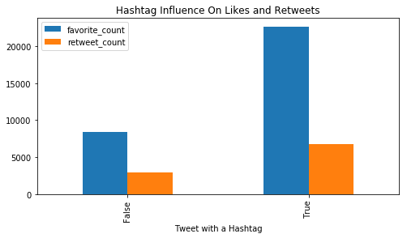

```python
df[["hashtag","favorite_count","retweet_count"]].groupby(by="hashtag").mean().plot(kind="bar",title="Hashtag Influence On Likes and Retweets", figsize=(8,4))
plt.xlabel("Tweet with a Hashtag");
```

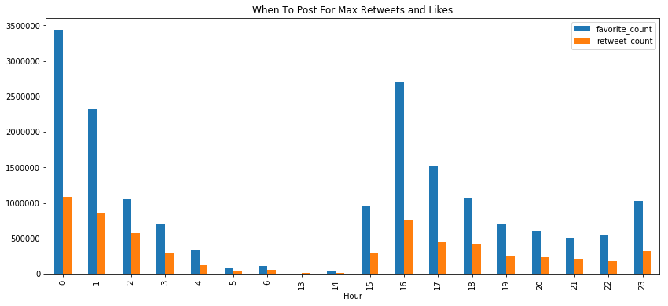

```python
df["hour"] = df.timestamp.dt.hour
df[["hour","favorite_count","retweet_count"]].groupby(by="hour").sum().plot.bar(figsize=(14,6), title="When To Post For Max Retweets and Likes")
plt.xlabel("Hour");
```

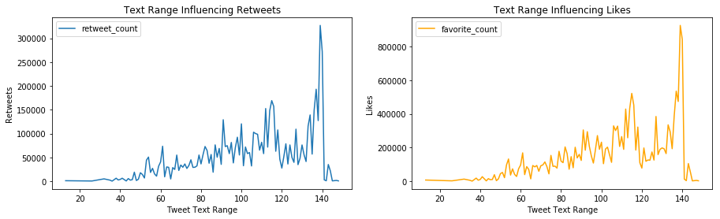

```python
fig, (ax1, ax2) = plt.subplots(1,2, figsize=(15,4))
df[["display_text_range","retweet_count"]].groupby(by="display_text_range").sum().plot(title="Text Range Influencing Retweets", ax=ax1)
df[["display_text_range","favorite_count"]].groupby(by="display_text_range").sum().plot(color="orange", title="Text Range Influencing Likes", ax=ax2)
ax1.set(xlabel='Tweet Text Range', ylabel='Retweets')
ax2.set(xlabel='Tweet Text Range', ylabel='Likes');
```